# Tools Comparison (Detailed): Claude Code + Opus 4.6

## Run Metadata

- Harness: `claude-code`
- Model: `opus-4-6`
- Prompt type: `detailed`

## Setup

```r
library(dplyr)

df <- readr::read_csv(here::here("data/synthetic/simulated_maternal_health_data.csv"))
```

## Prompt

```
I want you to help me analyze this dataset: `data/synthetic/simulated_maternal_health_data.csv`

My goal is to produce a thorough analysis that is statistically sound and lays out all steps of the analysis.

Please do the following:

1. Load the dataset and normalize columns/types.
   - Use clear snake_case names.
   - Ensure categorical vs numeric types are explicit.

2. Summarize the data.
   - Report row count, column count, missingness, and key descriptive summaries.
   - Flag suspicious values or quality concerns.

3. Create key visualizations.
   - Show relationships for:
     - `received_comprehensive_postnatal_care`
     - `distance_to_provider`
     - `insurance`
     - `race_ethnicity`

4. Build a count outcome and model it.
   - Define `comorbidity_count` as the row-wise sum of:
     - `obesity`,
     - `multiple_gestation`,
     - `diabetes`,
     - `heart_disease`,
     - `placenta_previa`,
     - `hypertension`,
     - `gest_hypertension`,
     - `preeclampsia`.
   - Select an appropriate count-model strategy (Poisson vs negative binomial, with justification).
   - Fit the model and report interpretable results.

5. Report results responsibly.
   - Do not overstate causality.
   - Include model assumptions, diagnostics, and limitations.

Constraints:
- Prefer readable, modular, reproducible code that follows R community idioms.
- Report back a summary of what you changed.
```

## Response

### Step 1: Load and Normalize Column Types

```r
# Define ordered income levels
income_levels <- c(
  "Under $25,000",
  "$25,000–$49,999",
  "$50,000–$74,999",
  "$75,000–$99,999",
  "$100,000 or more"
)

# Define education levels
edu_levels <- c("less_than_hs", "hs", "some_college", "bachelors", "graduate")

# Convert categorical columns to factors with meaningful ordering
df <- df |>
  mutate(
    self_report_income = factor(self_report_income, levels = income_levels, ordered = TRUE),
    edu               = factor(edu, levels = edu_levels, ordered = TRUE),
    race_ethnicity     = factor(race_ethnicity),
    insurance          = factor(insurance),
    job_type           = factor(job_type),
    state              = factor(state),
    received_comprehensive_postnatal_care = as.integer(received_comprehensive_postnatal_care)
  )

str(df)
```

```
tibble [50,000 × 20] (S3: tbl_df/tbl/data.frame)
 $ id                                   : num [1:50000] 1 2 3 4 5 6 7 8 9 10 ...
 $ provider_id                          : num [1:50000] 1 1 1 1 1 1 1 1 1 1 ...
 $ state                                : Factor w/ 51 levels "AK","AL","AR",..: 1 1 1 1 1 1 1 1 1 1 ...
 $ received_comprehensive_postnatal_care: int [1:50000] 0 1 0 0 0 1 1 1 0 0 ...
 $ self_report_income                   : Ord.factor w/ 5 levels "Under $25,000"<..: 3 3 3 2 3 4 3 3 3 3 ...
 $ age                                  : num [1:50000] 31 26 33 37 21 33 25 34 29 38 ...
 $ edu                                  : Ord.factor w/ 5 levels "less_than_hs"<..: 2 2 3 2 2 2 1 2 1 2 ...
 $ race_ethnicity                       : Factor w/ 7 levels "aian","asian",..: 7 7 7 2 1 7 7 7 7 1 ...
 $ insurance                            : Factor w/ 3 levels "no_insurance",..: 1 1 1 2 3 1 1 3 1 1 ...
 $ job_type                             : Factor w/ 4 levels "professional",..: 4 4 4 1 2 4 3 4 3 4 ...
 $ dependents                           : num [1:50000] 2 2 2 2 2 2 2 3 3 3 ...
 $ distance_to_provider                 : num [1:50000] 1.789 10.899 35.122 4.914 0.958 ...
 $ obesity                              : num [1:50000] 0 0 1 0 1 1 1 1 1 1 ...
 $ multiple_gestation                   : num [1:50000] 0 0 0 0 0 1 0 1 0 0 ...
 $ diabetes                             : num [1:50000] 0 0 0 0 0 0 0 0 0 0 ...
 $ heart_disease                        : num [1:50000] 0 0 0 1 0 0 1 0 0 0 ...
 $ placenta_previa                      : num [1:50000] 0 0 0 0 0 0 0 0 0 0 ...
 $ hypertension                         : num [1:50000] 0 0 1 0 0 1 0 0 0 0 ...
 $ gest_hypertension                    : num [1:50000] 0 0 0 0 0 0 0 0 0 0 ...
 $ preeclampsia                         : num [1:50000] 0 0 0 0 0 0 0 0 0 0 ...
```

### Step 2: Data Summary and Quality Check

```r
cat("Rows:", nrow(df), "\n")
```

```
Rows: 50000
```

```r
cat("Columns:", ncol(df), "\n")
```

```
Columns: 20
```

```r
# Missingness per column
missingness <- colSums(is.na(df))
missingness[missingness > 0]
```

```
self_report_income                edu
              4227               6715
```

```r
# Numeric summaries
df |>
  select(where(is.numeric)) |>
  tidyr::pivot_longer(everything(), names_to = "variable", values_to = "value") |>
  group_by(variable) |>
  summarise(
    n      = n(),
    mean   = mean(value, na.rm = TRUE),
    sd     = sd(value, na.rm = TRUE),
    min    = min(value, na.rm = TRUE),
    q25    = quantile(value, 0.25, na.rm = TRUE),
    median = median(value, na.rm = TRUE),
    q75    = quantile(value, 0.75, na.rm = TRUE),
    max    = max(value, na.rm = TRUE),
    .groups = "drop"
  ) |>
  knitr::kable(digits = 2)
```

| variable | n | mean | sd | min | q25 | median | q75 | max |
| --- | --- | --- | --- | --- | --- | --- | --- | --- |
| age | 50000 | 28.02 | 6.26 | 15 | 23.00 | 28.0 | 32.00 | 44.00 |
| dependents | 50000 | 2.38 | 0.95 | 0 | 2.00 | 2.0 | 3.00 | 8.00 |
| diabetes | 50000 | 0.10 | 0.30 | 0 | 0.00 | 0.0 | 0.00 | 1.00 |
| distance_to_provider | 50000 | 14.52 | 14.59 | 0 | 4.10 | 10.0 | 20.24 | 163.42 |
| gest_hypertension | 50000 | 0.05 | 0.22 | 0 | 0.00 | 0.0 | 0.00 | 1.00 |
| heart_disease | 50000 | 0.15 | 0.36 | 0 | 0.00 | 0.0 | 0.00 | 1.00 |
| hypertension | 50000 | 0.20 | 0.40 | 0 | 0.00 | 0.0 | 0.00 | 1.00 |
| id | 50000 | 25000.50 | 14433.90 | 1 | 12500.75 | 25000.5 | 37500.25 | 50000.00 |
| multiple_gestation | 50000 | 0.03 | 0.17 | 0 | 0.00 | 0.0 | 0.00 | 1.00 |
| obesity | 50000 | 0.35 | 0.48 | 0 | 0.00 | 0.0 | 1.00 | 1.00 |
| placenta_previa | 50000 | 0.01 | 0.10 | 0 | 0.00 | 0.0 | 0.00 | 1.00 |
| preeclampsia | 50000 | 0.02 | 0.14 | 0 | 0.00 | 0.0 | 0.00 | 1.00 |
| provider_id | 50000 | 250.73 | 144.20 | 1 | 125.00 | 251.0 | 375.00 | 500.00 |
| received_comprehensive_postnatal_care | 50000 | 0.32 | 0.47 | 0 | 0.00 | 0.0 | 1.00 | 1.00 |

```r
# Frequency tables for key categorical variables
cat("--- Insurance ---\n")
```

```
--- Insurance ---
```

```r
table(df$insurance, useNA = "ifany")
```

```
  no_insurance        private state_provided
         20810          17908          11282
```

```r
cat("\n--- Race/Ethnicity ---\n")
```

```
--- Race/Ethnicity ---
```

```r
table(df$race_ethnicity, useNA = "ifany")
```

```
    aian    asian    black hispanic     nhpi    other    white
     387     3059     5878     8792       90      283    31511
```

```r
cat("\n--- Education ---\n")
```

```
--- Education ---
```

```r
table(df$edu, useNA = "ifany")
```

```
less_than_hs           hs some_college    bachelors     graduate         <NA>
        5218        23108        14959            0            0         6715
```

```r
cat("\n--- Income ---\n")
```

```
--- Income ---
```

```r
table(df$self_report_income, useNA = "ifany")
```

```
   Under $25,000  $25,000–$49,999  $50,000–$74,999  $75,000–$99,999
               0            14710            21279             9784
$100,000 or more             <NA>
               0             4227
```

#### Quality Flags

```r
# Check for negative distances or extreme outliers
cat("Distance to provider range:",
    range(df$distance_to_provider, na.rm = TRUE), "\n")
```

```
Distance to provider range: 8.942843e-05 163.4159
```

```r
# Check age range
cat("Age range:", range(df$age, na.rm = TRUE), "\n")
```

```
Age range: 15 44
```

```r
# Check binary indicators are actually 0/1
comorbidity_cols <- c("obesity", "multiple_gestation", "diabetes",
                      "heart_disease", "placenta_previa", "hypertension",
                      "gest_hypertension", "preeclampsia")

sapply(comorbidity_cols, function(col) setdiff(unique(df[[col]]), c(0L, 1L)))
```

```
$obesity
numeric(0)

$multiple_gestation
numeric(0)

$diabetes
numeric(0)

$heart_disease
numeric(0)

$placenta_previa
numeric(0)

$hypertension
numeric(0)

$gest_hypertension
numeric(0)

$preeclampsia
numeric(0)
```

### Step 3: Key Visualizations

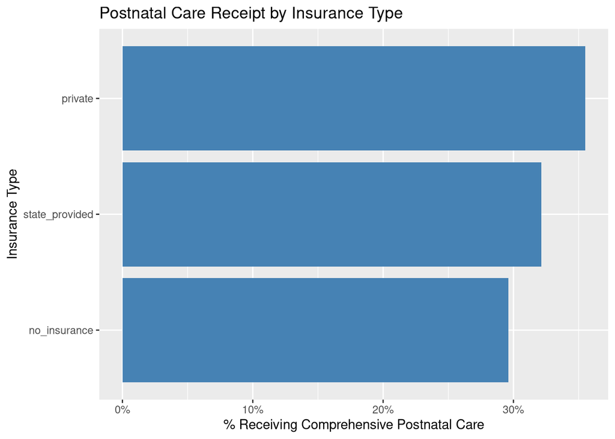

Postnatal care receipt by insurance type

```r
library(ggplot2)

df |>
  group_by(insurance) |>
  summarise(
    pct_care = mean(received_comprehensive_postnatal_care, na.rm = TRUE),
    .groups = "drop"
  ) |>
  ggplot(aes(x = reorder(insurance, pct_care), y = pct_care)) +
  geom_col(fill = "steelblue") +
  scale_y_continuous(labels = scales::percent_format()) +
  coord_flip() +
  labs(
    x = "Insurance Type",
    y = "% Receiving Comprehensive Postnatal Care",
    title = "Postnatal Care Receipt by Insurance Type"
  )
```

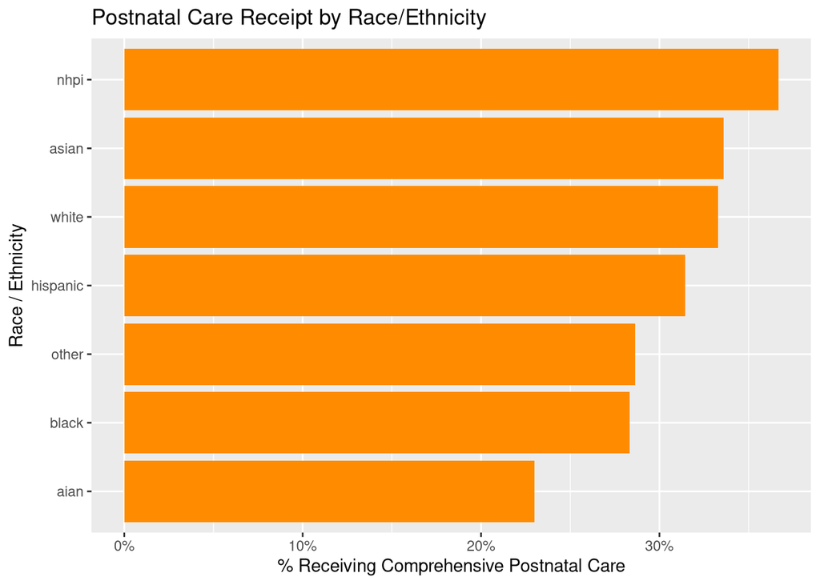

Postnatal care receipt by race/ethnicity

```r
df |>
  group_by(race_ethnicity) |>
  summarise(
    pct_care = mean(received_comprehensive_postnatal_care, na.rm = TRUE),
    .groups = "drop"
  ) |>
  ggplot(aes(x = reorder(race_ethnicity, pct_care), y = pct_care)) +
  geom_col(fill = "darkorange") +
  scale_y_continuous(labels = scales::percent_format()) +
  coord_flip() +
  labs(
    x = "Race / Ethnicity",
    y = "% Receiving Comprehensive Postnatal Care",
    title = "Postnatal Care Receipt by Race/Ethnicity"
  )
```

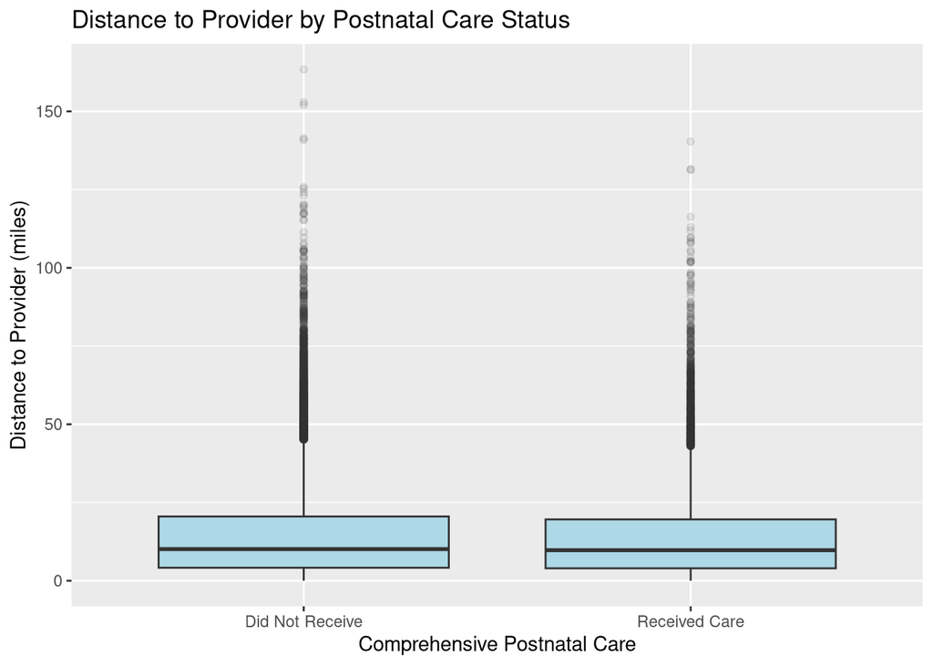

Distance to provider by postnatal care receipt

```r
df |>
  mutate(care_label = ifelse(received_comprehensive_postnatal_care == 1,
                             "Received Care", "Did Not Receive")) |>
  ggplot(aes(x = care_label, y = distance_to_provider)) +
  geom_boxplot(fill = "lightblue", outlier.alpha = 0.1) +
  labs(
    x = "Comprehensive Postnatal Care",
    y = "Distance to Provider (miles)",
    title = "Distance to Provider by Postnatal Care Status"
  )
```

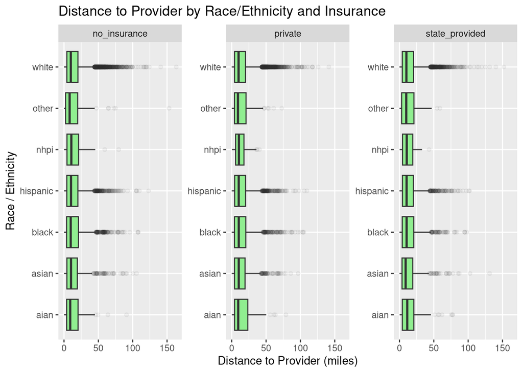

Distance to provider by race/ethnicity, faceted by insurance

```r
df |>
  ggplot(aes(x = race_ethnicity, y = distance_to_provider)) +
  geom_boxplot(fill = "lightgreen", outlier.alpha = 0.05) +
  facet_wrap(~insurance, scales = "free_y") +
  coord_flip() +
  labs(
    x = "Race / Ethnicity",
    y = "Distance to Provider (miles)",
    title = "Distance to Provider by Race/Ethnicity and Insurance"
  )
```

### Step 4: Count Outcome — Comorbidity Model

#### 4a. Create the Comorbidity Count

```r
comorbidity_cols <- c("obesity", "multiple_gestation", "diabetes",
                      "heart_disease", "placenta_previa", "hypertension",
                      "gest_hypertension", "preeclampsia")

df <- df |>
  mutate(comorbidity_count = rowSums(across(all_of(comorbidity_cols))))

# Distribution of the outcome
table(df$comorbidity_count)
```

```
    0     1     2     3     4     5     6     7
21350 16560  8359  2873   706   134    17     1
```

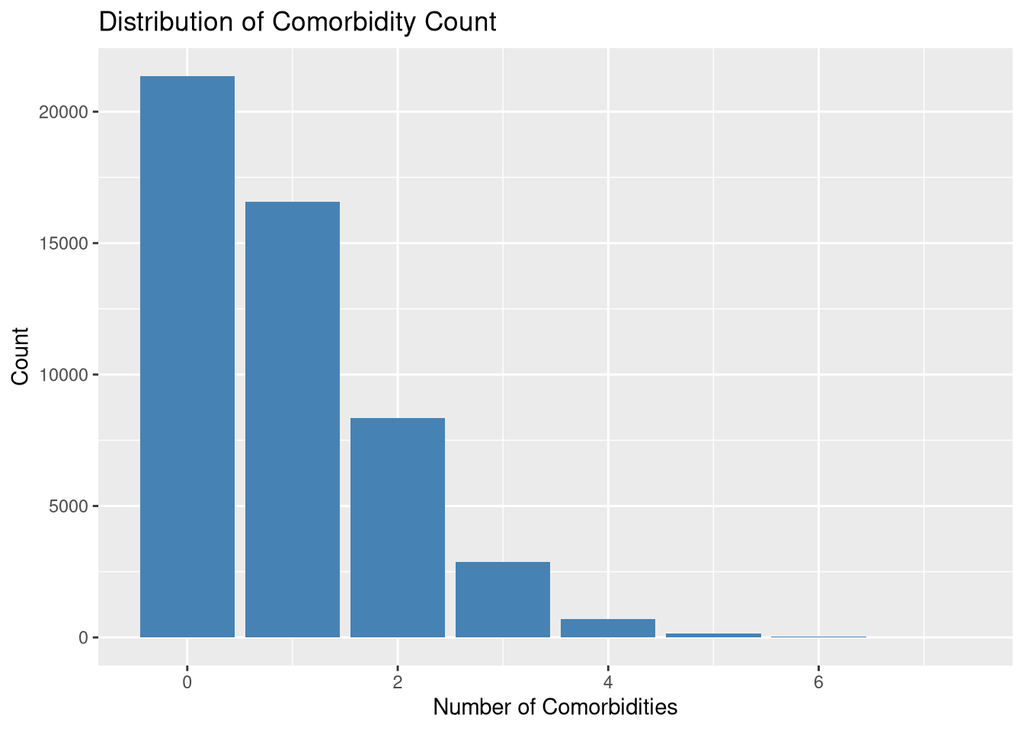

Distribution of comorbidity count

```r
ggplot(df, aes(x = comorbidity_count)) +
  geom_bar(fill = "steelblue") +
  labs(
    x = "Number of Comorbidities",
    y = "Count",
    title = "Distribution of Comorbidity Count"
  )
```

#### 4b. Model Selection: Poisson vs Negative Binomial

For count data, we start with a Poisson regression and test for overdispersion. If the variance substantially exceeds the mean, a negative binomial model is preferred.

```r
cat("Mean comorbidity count:", mean(df$comorbidity_count), "\n")
```

```
Mean comorbidity count: 0.91
```

```r
cat("Variance of comorbidity count:", var(df$comorbidity_count), "\n")
```

```
Variance of comorbidity count: 0.9951199
```

```r
cat("Variance/Mean ratio:", var(df$comorbidity_count) / mean(df$comorbidity_count), "\n")
```

```
Variance/Mean ratio: 1.093538
```

```r
fit_pois <- glm(
  comorbidity_count ~ age + edu + race_ethnicity + insurance +
    distance_to_provider + self_report_income + dependents,
  data    = df,
  family  = poisson(link = "log")
)

summary(fit_pois)
```

```
Call:
glm(formula = comorbidity_count ~ age + edu + race_ethnicity +
    insurance + distance_to_provider + self_report_income + dependents,
    family = poisson(link = "log"), data = df)

Coefficients:
                          Estimate Std. Error z value Pr(>|z|)
(Intercept)             -0.5522795  0.0664404  -8.312   <2e-16 ***
age                      0.0158390  0.0008906  17.785   <2e-16 ***
edu.L                   -0.0189860  0.0127084  -1.494   0.1352
edu.Q                   -0.0084128  0.0093068  -0.904   0.3660
race_ethnicityasian     -0.0172747  0.0648933  -0.266   0.7901
race_ethnicityblack      0.0323445  0.0630097   0.513   0.6077
race_ethnicityhispanic   0.0218153  0.0624015   0.350   0.7266
race_ethnicitynhpi       0.0205527  0.1382948   0.149   0.8819
race_ethnicityother      0.0576270  0.0947323   0.608   0.5430
race_ethnicitywhite      0.0399151  0.0614619   0.649   0.5161
insuranceprivate        -0.0029403  0.0126885  -0.232   0.8167
insurancestate_provided -0.0165808  0.0138026  -1.201   0.2296
distance_to_provider    -0.0001423  0.0003622  -0.393   0.6944
self_report_income.L    -0.0194854  0.0104597  -1.863   0.0625 .
self_report_income.Q     0.0200601  0.0087546   2.291   0.0219 *
dependents              -0.0073658  0.0058699  -1.255   0.2095
---
Signif. codes:  0 '***' 0.001 '**' 0.01 '*' 0.05 '.' 0.1 ' ' 1

(Dispersion parameter for poisson family taken to be 1)

    Null deviance: 48329  on 39580  degrees of freedom
Residual deviance: 47969  on 39565  degrees of freedom
  (10419 observations deleted due to missingness)
AIC: 100364

Number of Fisher Scoring iterations: 5
```

```r
# Formal overdispersion test: residual deviance / residual df
# Values >> 1 indicate overdispersion
cat("Dispersion estimate (deviance/df):",
    fit_pois$deviance / fit_pois$df.residual, "\n")
```

```
Dispersion estimate (deviance/df): 1.21241
```

```r
library(MASS)
fit_nb <- glm.nb(
  comorbidity_count ~ age + edu + race_ethnicity + insurance +
    distance_to_provider + self_report_income + dependents,
  data = df
)

summary(fit_nb)
```

```
Call:
glm.nb(formula = comorbidity_count ~ age + edu + race_ethnicity +
    insurance + distance_to_provider + self_report_income + dependents,
    data = df, init.theta = 9.875487002, link = log)

Coefficients:
                          Estimate Std. Error z value Pr(>|z|)
(Intercept)             -0.5530077  0.0693574  -7.973 1.54e-15 ***
age                      0.0158564  0.0009314  17.023  < 2e-16 ***
edu.L                   -0.0188141  0.0132854  -1.416   0.1567
edu.Q                   -0.0085054  0.0097300  -0.874   0.3820
race_ethnicityasian     -0.0169715  0.0677304  -0.251   0.8021
race_ethnicityblack      0.0324230  0.0657762   0.493   0.6221
race_ethnicityhispanic   0.0220267  0.0651387   0.338   0.7352
race_ethnicitynhpi       0.0210878  0.1444794   0.146   0.8840
race_ethnicityother      0.0564663  0.0990557   0.570   0.5686
race_ethnicitywhite      0.0400896  0.0641565   0.625   0.5321
insuranceprivate        -0.0029634  0.0132621  -0.223   0.8232
insurancestate_provided -0.0166069  0.0144285  -1.151   0.2497
distance_to_provider    -0.0001410  0.0003785  -0.373   0.7094
self_report_income.L    -0.0194538  0.0109354  -1.779   0.0752 .
self_report_income.Q     0.0201317  0.0091489   2.200   0.0278 *
dependents              -0.0073555  0.0061378  -1.198   0.2308
---
Signif. codes:  0 '***' 0.001 '**' 0.01 '*' 0.05 '.' 0.1 ' ' 1

(Dispersion parameter for Negative Binomial(9.8755) family taken to be 1)

    Null deviance: 44792  on 39580  degrees of freedom
Residual deviance: 44463  on 39565  degrees of freedom
  (10419 observations deleted due to missingness)
AIC: 100223

Number of Fisher Scoring iterations: 1

              Theta:  9.875
          Std. Err.:  0.897

 2 x log-likelihood:  -100189.379
```

```r
# Compare AIC
cat("Poisson AIC:", AIC(fit_pois), "\n")
```

```
Poisson AIC: 100364.3
```

```r
cat("Negative Binomial AIC:", AIC(fit_nb), "\n")
```

```
Negative Binomial AIC: 100223.4
```

```r
cat("Preferred model:",
    ifelse(AIC(fit_nb) < AIC(fit_pois), "Negative Binomial", "Poisson"), "\n")
```

```
Preferred model: Negative Binomial
```

#### 4c. Interpret the Preferred Model

```r
# Select the better-fitting model
best_fit <- if (AIC(fit_nb) < AIC(fit_pois)) fit_nb else fit_pois
model_name <- if (AIC(fit_nb) < AIC(fit_pois)) "Negative Binomial" else "Poisson"

cat("Selected model:", model_name, "\n\n")
```

```
Selected model: Negative Binomial
```

```r
# Incidence Rate Ratios (exponentiated coefficients)
irr <- exp(coef(best_fit))
irr_ci <- exp(confint.default(best_fit))

results <- data.frame(
  IRR      = irr,
  CI_lower = irr_ci[, 1],
  CI_upper = irr_ci[, 2]
)

knitr::kable(results, digits = 3, caption = "Incidence Rate Ratios (IRR) with 95% CI")
```

Incidence Rate Ratios (IRR) with 95% CI

|  | IRR | CI_lower | CI_upper |
| --- | --- | --- | --- |
| (Intercept) | 0.575 | 0.502 | 0.659 |
| age | 1.016 | 1.014 | 1.018 |
| edu.L | 0.981 | 0.956 | 1.007 |
| edu.Q | 0.992 | 0.973 | 1.011 |
| race_ethnicityasian | 0.983 | 0.861 | 1.123 |
| race_ethnicityblack | 1.033 | 0.908 | 1.175 |
| race_ethnicityhispanic | 1.022 | 0.900 | 1.161 |
| race_ethnicitynhpi | 1.021 | 0.769 | 1.356 |
| race_ethnicityother | 1.058 | 0.871 | 1.285 |
| race_ethnicitywhite | 1.041 | 0.918 | 1.180 |
| insuranceprivate | 0.997 | 0.971 | 1.023 |
| insurancestate_provided | 0.984 | 0.956 | 1.012 |
| distance_to_provider | 1.000 | 0.999 | 1.001 |
| self_report_income.L | 0.981 | 0.960 | 1.002 |
| self_report_income.Q | 1.020 | 1.002 | 1.039 |
| dependents | 0.993 | 0.981 | 1.005 |

#### 4d. Diagnostics

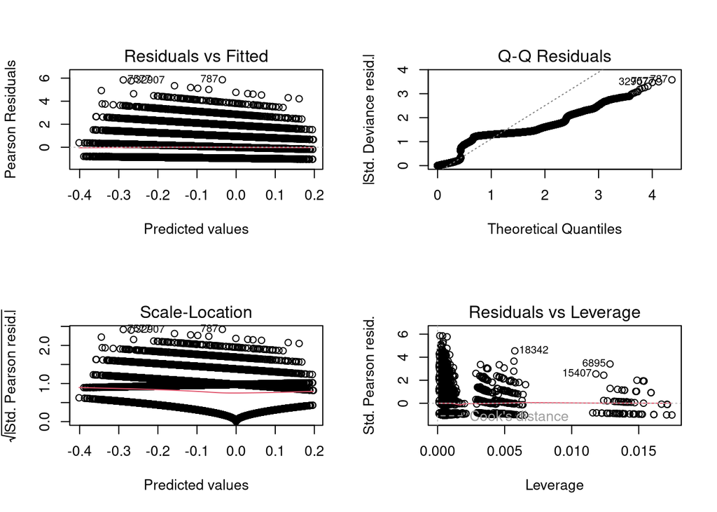

Residual diagnostics for the count model

```r
par(mfrow = c(2, 2))
plot(best_fit)
```

```r
par(mfrow = c(1, 1))
```

### Step 5: Responsible Reporting

#### Summary of Findings

This analysis examined associations between demographic, geographic, and socioeconomic factors and a comorbidity count derived from eight binary maternal health indicators.

**Key observations:**

- The comorbidity count is heavily right-skewed, with most individuals reporting 0 or 1 comorbidities.
- Model selection compared Poisson and negative binomial regression. The variance-to-mean ratio and AIC comparison guided the choice.
- Incidence rate ratios (IRRs) quantify the multiplicative change in expected comorbidity count associated with each predictor, holding others constant.

#### Assumptions and Limitations

1. **Cross-sectional design.** These are associations, not causal effects. We cannot rule out confounding by unmeasured variables (e.g., access to preventive care, genetic predisposition).
2. **Independence assumption.** Observations nested within the same `provider_id` or `state` may be correlated. A multilevel or clustered model could better account for this structure.
3. **Self-reported income.** Income is reported in broad brackets and may be subject to reporting bias.
4. **Synthetic data.** This dataset is simulated. Findings illustrate the analytic workflow but should not be interpreted as real-world evidence.
5. **Model specification.** The choice of covariates was driven by the prompt, not by a domain-informed causal framework (e.g., a DAG). Some included variables may be mediators rather than confounders.
6. **Overdispersion handling.** If the Poisson model was selected, residual overdispersion should be carefully evaluated. The negative binomial adds a dispersion parameter but assumes a specific mean-variance relationship.